# ML_HW03_0129

### Q2

**Explaination of cross validation** :  
Cross Validation is a model evaluation method. It is the process of training model on a subset of dataset repeatedly. This process consists of the following steps : 1).dividing the dataset into several folds/subsets, 2).taking out one fold out of the dataset to train the model on, 3).placing the fold back to the dataset and 4).training the model on another fold taken from the dataset.  
The goal of cross validation is to be able to measure the out-of-sample performance of model while saving the cost of requiring extra datasets.

**Potential Problems** :  
One potential problem of cross validation is that it’s not a fully out-of-sample model evaluation method. As the fold of dataset that has been left out as test set will be put back to training set and used again as part of training set, the performance of model measured based on the this setup cannot be seen as fully out-of-sample performance.  
Another problem of cross validation is that it’s relatively time-consuming compared with in-sample measure, especially for cross validation method like Leave-one-out cross validation. When there is a large-sized dataset, fitting K times can become unfeasible even K in 5-10.  
It can also be unstable. There can be large variability on the model chose when we do CV on many different samples.

### Q3

```r
#specify the cross-validation method
ctrl <- trainControl(method = "cv", number = 8)
#fit a regression model and use k-fold CV to evaluate performance
model_cv <- train(heart_attack~., data = train, method = "lm", trControl = ctrl)
#view summary of k-fold CV
print(model_cv)
```

```
## Linear Regression
##
## 189 samples
##  16 predictor
##
## No pre-processing
## Resampling: Cross-Validated (8 fold)
## Summary of sample sizes: 165, 165, 165, 167, 164, 166, ...
## Resampling results:
##
##   RMSE      Rsquared  MAE
##   1.712539  0.845123  0.8974778
##
## Tuning parameter 'intercept' was held constant at a value of TRUE
```

```r
model_cv$results['Rsquared']
```

```
##   Rsquared
## 1 0.845123
```

```r
#view final model
model_cv$finalModel
```

```
##
## Call:
## lm(formula = .outcome ~ ., data = dat)
##
## Coefficients:
##    (Intercept)       past_pain         density             age          weight
##       7.877698       -0.129072      -10.016106       -0.004205        0.070270
##         height     fat_free_wt        neck_dim       chest_dim       abdom_dim
##      -0.153632       -0.074175        0.128943        0.120933        0.094493
##        hip_dim       thigh_dim        knee_dim       ankle_dim      biceps_dim
##       0.052610        0.103280       -0.146369        0.100140        0.051328
##    forearm_dim  wrist_dim...19
##       0.020403        0.193104
```

```r
#view predictions for each fold
model_cv$resample
```

```
##        RMSE  Rsquared       MAE Resample
## 1 0.7808447 0.9173623 0.6127808    Fold1
## 2 1.0956486 0.8588043 0.8003410    Fold2
## 3 0.9212176 0.9422070 0.7066507    Fold3
## 4 1.5358726 0.8623538 1.0156315    Fold4
## 5 0.9379491 0.9253556 0.7821995    Fold5
## 6 5.8220466 0.5979402 1.4562398    Fold6
## 7 0.9028146 0.9180597 0.7144164    Fold7
## 8 1.7039155 0.7389010 1.0915625    Fold8
```

```r
#OOS R^2
OOS_R_squared_cv <- mean(model_cv$resample$Rsquared) #0.845123
OOS_R_squared_cv
```

```
## [1] 0.845123
```

### Q4

**Explaination**:  
Lasso (Least Absolute Shrinkage and Selection Operator) regression is a regularization technique for feature selection. Lasso procedure aims to result in sparse models with few coefficients and avoid model overfitting by adding penalties that is equal to penalty weight times the absolute value of the magnitude of the coefficient for each additional variable.  
The goal is to minimize the following :  
Lasso path = Residual Sum of Squares + λ * (Sum of the absolute value of the magnitude of coefficients), where λ denotes the penalty weights. = Σ(yi – ŷi)2 + λΣ|βj|

**How**:  
We generate the following steps to select a value for λ that produces the lowest possible test MSE (mean squared error). 1). Set a sequence of penalties λ1,…, λt.  
2). For each of k = 1,…K folds,  
- Fit the path beta_1,…, beta_T on all data except fold k  
- Get the fitted deviance on left out data  
This gives us K draws of OOS deviance for each λt.  
3). Use the results to choose the best λ  
4). then re-fit the model to all of the data by minimizing the lasso regression

**Pros**:  
1. It avoids model overfitting.  
2. It also does feature selection more efficiently than stepwise selection (forward or backward selection) as it’s automatic.  
3. It has been found that Lasso produces the highest model prediction accuracy under the widest range of circumstance compared to stepwise selection. (“Extended Comparisons of Best Subset Selection, Forward Stepwise Selection, and the Lasso” by Hastie et al, 2017)

**Cons**:  
1. It’s hard to interpret the selection result of model, for example, why lasso selects some features instead of other features?  
2. When there are features highly correlated with each other, lasso may randomly select one of them into model.

### Q5

#### 1).

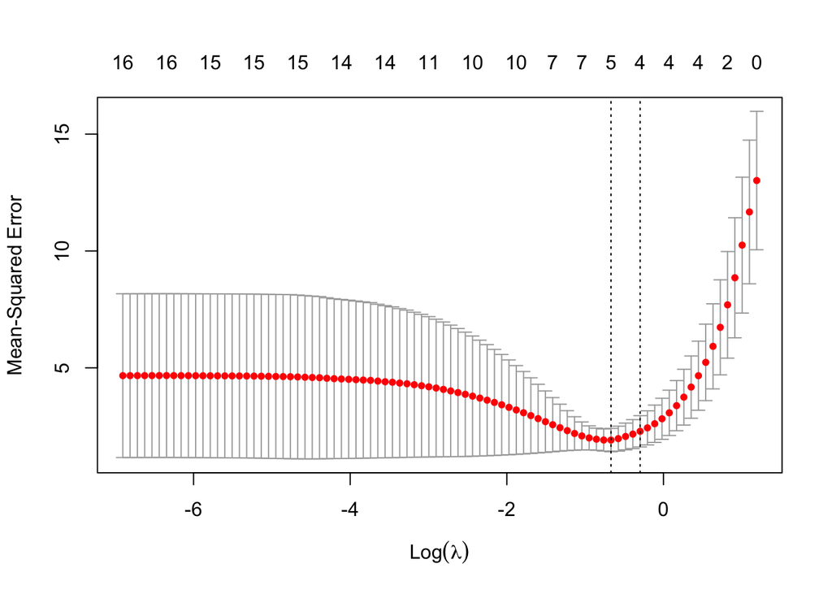

```r
#define response variable
train_y <- train$heart_attack
#define matrix of predictor variables
train_x <- data.matrix(train[1:16])
#define response variable in test set
test_y <-  test$heart_attack
#define matrix of predictor variables in test set
test_x <- data.matrix(test[1:16])

#Fit lasso regression
lasso_cv <- cv.glmnet(train_x, train_y, alpha=1)
#Pproduce plot of test MSE by lambda value
plot(lasso_cv)
```

```r
#1. Find the lambda value that minimizes average OOS deviance
lambda_min <- lasso_cv$lambda.min
lambda_min
```

```
## [1] 0.5117957
```

```r
# Find the model based on lambda_min
model_lambda_min <- glmnet(x = train_x, y = train_y, alpha = 1, lambda = lambda_min)
coef(model_lambda_min)
```

```
## 17 x 1 sparse Matrix of class "dgCMatrix"
##                          s0
## (Intercept)    -9.230306023
## past_pain       .
## density         .
## age             .
## weight          .
## height          .
## fat_free_wt     .
## neck_dim        .
## chest_dim       0.140322245
## abdom_dim       0.101487990
## hip_dim         0.060123740
## thigh_dim       0.085204395
## knee_dim        .
## ankle_dim       .
## biceps_dim      0.002497108
## forearm_dim     .
## wrist_dim...19  .
```

```r
# Use lasso regression model to predict response value
predictions_min <- predict(model_lambda_min, s = lambda_min, newx = test_x)
# Get the OOS residual deviance
OOS_res_deviance_min <- sum((test$heart_attack - predictions_min)^ 2)
## Calculate OOS R-squared
OOS_R_squared_min <- 1 - (OOS_res_deviance_min / OOS_null_deviance)
OOS_R_squared_min #0.8834594
```

```
## [1] 0.8834594
```

```r
#2. Find the biggest lambda with average OOS deviance no more than 1SD away from the minimum
lambda_1se <- lasso_cv$lambda.1se
lambda_1se
```

```
## [1] 0.742528
```

```r
# Find the model based on lambda_1se
model_lambda_1se <- glmnet(x = train_x, y = train_y, alpha = 1, lambda = lambda_1se)
coef(model_lambda_1se)
```

```
## 17 x 1 sparse Matrix of class "dgCMatrix"
##                         s0
## (Intercept)    -6.11737296
## past_pain       .
## density         .
## age             .
## weight          .
## height          .
## fat_free_wt     .
## neck_dim        .
## chest_dim       0.12808244
## abdom_dim       0.09796306
## hip_dim         0.05715104
## thigh_dim       0.06510576
## knee_dim        .
## ankle_dim       .
## biceps_dim      .
## forearm_dim     .
## wrist_dim...19  .
```

```r
# Use lasso regression model to predict response value
predictions_1se <- predict(model_lambda_1se, s = lambda_1se, newx = test_x)
# Get the OOS residual deviance
OOS_res_deviance_1se <- sum((test$heart_attack - predictions_1se)^ 2)
## Calculate OOS R-squared
OOS_R_squared_1se <- 1 - (OOS_res_deviance_1se / OOS_null_deviance)
OOS_R_squared_1se #0.8692755
```

```
## [1] 0.8692755
```

#### 2).

```r
#R^2 for model in Q1
OOS_R_squared #0.933342
```

```
## [1] 0.933342
```

```r
#R^2 for model in Q3
OOS_R_squared_cv #0.845123
```

```
## [1] 0.845123
```

```r
#R^2 for model in Q5
OOS_R_squared_min #0.8834594
```

```
## [1] 0.8834594
```

**Comparison**: Model in Q1 has the highest R^2 (0.933342), Model in Q3 has the lowest R^2 (0.845123).

### Q6

**Answer**:  
AIC (Akaike’s Information Criterion) is a in-sample statistic measure that approximates OOS deviance.  
It’s calculated as “Deviance + 2df”, where df is the degree of freedom used in model fit. The higher AIC is, the better the model fits.  
AIC overfits in high dimensions because in big data, df(number of parameters) can be huge, so df almost equals to sample size. In this case, AIC is a bad approximation, therefore, we use AIC corrected (AICc).  
AICc is calculated as “Deviance + 2df * (n/n-df-1)”.